# example slides

**Call Tracking: Bayesian AB Testing**

**DS223 Marketing Analytics**

**Professor: Karen Hovhannisyan**

December 13, 2023

**Presenting to you our team**

Project | Product / Project Manager: Anush Aghinyan

Database Developer: Anahit Navoyan  
API Developer: Mher Movsisyan  
Data Scientists: Yeva Avetisyan, Naira Barseghyan

[figure not shown]

**Objective**

Maximize the effectiveness of ad campaigns by identifying which ads generate more calls.

**Description**

Our project uses Bayesian AB Testing for call tracking. It assigns different phone numbers to different ads and analyzes the amount of calls each ad receives. Based on the gained insights, the algorithm chooses the most successful ad.

**Package Functionality**

**1. Database Shchema**

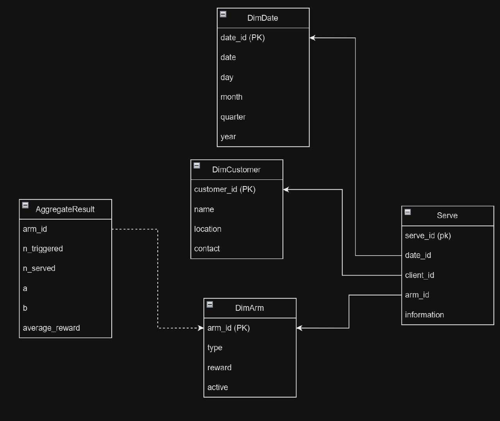

```python
!pip install bayesian_ab_testing==1.1.2
import bayesian_ab_testing
```

[output not shown]

**2. Data Generation**

```python
from bayesian_ab_testing.data_preparation import generate_arm, generate_customer, generate_date, generate_serve

arm = generate_arm(4)
cust = generate_customer(2)
date = generate_date(10)
serve = generate_serve(12, date_id=date["date_id"], customer_id=cust["customer_id"], arm_id=arm["arm_id"], p=0.5)

cust
```

```
{'customer_id': 2,
 'name': 'Hannah Smith',
 'location': '85982 William Stream',
 'contact': '(656)895-8207'}
```

**3. Linking to Database**

```python
from bayesian_ab_testing.data_preparation import SqlHandler

cust_tbl = SqlHandler("DimCustomer")
cust_tbl.insert_one(**cust)
cust_tbl.select_one(cust["customer_id"])
```

```
2023-12-13 11:43:23,151 - sql_interactions.py - get_table_columns - INFO - (the list of columns: ['customer_id', 'name', 'location', 'contact']) - line: 77
INFO:sql_interactions.py:the list of columns: ['customer_id', 'name', 'location', 'contact']
```

```
{'customer_id': 2,
 'name': 'Hannah Smith',
 'location': '85982 William Stream',
 'contact': '(656)895-8207'}
```

**4. Running the Algorithm**

```python
from bayesian_ab_testing.models.TS_Bernoulli import ThompsonAlgo, ThompsonArm
from bayesian_ab_testing.api import cnxn

a = ThompsonArm(2, cnxn, type="Instagram", reward=3, customer_id=0)
b = ThompsonArm(3, cnxn, type="Facebook", reward=4, customer_id=0)
c = ThompsonArm(4, cnxn, type="TikTok", reward=1, customer_id=0)

c = ThompsonAlgo(cnxn, customer_id=0)
c.get_best_arm()
```

[output not shown]

```
{'serve_id': 0,
 'date_id': 0,
 'customer_id': 0,
 'arm_id': 4,
 'information': None,
 'result': None}
```

**6. Application Scenarios**

Example 1

**Background:**

Our customer is a marketing manager for a local restaurant. The restaurant has been in business for several years. They are exploring new ways to increase customer engagement and foot traffic. Traditional marketing methods like distributing fliers and investing in billboard advertisements have been successful in the past, but they want to determine which channel is more effective in driving customer calls and reservations.

**Objective:**

The goal is to optimize the marketing budget and focus on the channel that generates more calls, ultimately leading to increased reservations and revenue.

**Implementation:**

Step 1: A/B Testing Setup  
Step 2: Call Tracking and Analysis  
Step 3: Evaluation and Decision Making  
Step 4: Decision and Future Strategy

Example 2

**Background:**

Our customer is a marketing director for an upscale spa and wellness center. The spa has a loyal customer base, and they want to introduce a set of new premium services to their customers. To optimize the marketing strategy, they want to determine the effectiveness of promoting these services through email and direct mail campaigns targeted at existing customers.

**Objective:**

The goal is to identify the most effective communication channel for promoting new services to customers, considering both cost effectiveness and customer engagement.

**Implementation:**

Step 1: A/B Testing Setup  
Step 2: Call Tracking and Analysis  
Step 3: Evaluation and Decision Making  
Step 4: Decision and Future Strategy

**Thank you!**